# Tugas SML_Metode Validasi

Umi Makhmudah (3338240037)

2026-05-30

```r
library(readxl)
library(cluster)
library(factoextra)
library(fpc)

data <- read.csv("C:/Users/Mima/Downloads/Wholesale customers data.csv")

str(data)
```

```
## 'data.frame':    440 obs. of  8 variables:
##  $ Channel         : int  2 2 2 1 2 2 2 2 1 2 ...
##  $ Region          : int  3 3 3 3 3 3 3 3 3 3 ...
##  $ Fresh           : int  12669 7057 6353 13265 22615 9413 12126 7579 5963 6006 ...
##  $ Milk            : int  9656 9810 8808 1196 5410 8259 3199 4956 3648 11093 ...
##  $ Grocery         : int  7561 9568 7684 4221 7198 5126 6975 9426 6192 18881 ...
##  $ Frozen          : int  214 1762 2405 6404 3915 666 480 1669 425 1159 ...
##  $ Detergents_Paper: int  2674 3293 3516 507 1777 1795 3140 3321 1716 7425 ...
##  $ Delicassen      : int  1338 1776 7844 1788 5185 1451 545 2566 750 2098 ...
```

```r
summary(data)
```

```
##     Channel          Region          Fresh             Milk
##  Min.   :1.000   Min.   :1.000   Min.   :     3   Min.   :   55
##  1st Qu.:1.000   1st Qu.:2.000   1st Qu.:  3128   1st Qu.: 1533
##  Median :1.000   Median :3.000   Median :  8504   Median : 3627
##  Mean   :1.323   Mean   :2.543   Mean   : 12000   Mean   : 5796
##  3rd Qu.:2.000   3rd Qu.:3.000   3rd Qu.: 16934   3rd Qu.: 7190
##  Max.   :2.000   Max.   :3.000   Max.   :112151   Max.   :73498
##     Grocery          Frozen        Detergents_Paper    Delicassen
##  Min.   :    3   Min.   :   25.0   Min.   :    3.0   Min.   :    3.0
##  1st Qu.: 2153   1st Qu.:  742.2   1st Qu.:  256.8   1st Qu.:  408.2
##  Median : 4756   Median : 1526.0   Median :  816.5   Median :  965.5
##  Mean   : 7951   Mean   : 3071.9   Mean   : 2881.5   Mean   : 1524.9
##  3rd Qu.:10656   3rd Qu.: 3554.2   3rd Qu.: 3922.0   3rd Qu.: 1820.2
##  Max.   :92780   Max.   :60869.0   Max.   :40827.0   Max.   :47943.0
```

```r
colSums(is.na(data))
```

```
##          Channel           Region            Fresh             Milk
##                0                0                0                0
##          Grocery           Frozen Detergents_Paper       Delicassen
##                0                0                0                0
```

## Pemilihan Variabel

```r
data_clust <- data[, c("Fresh",
                       "Milk",
                       "Grocery",
                       "Frozen",
                       "Detergents_Paper",
                       "Delicassen")]
```

Dipilih 6 variabel: Fresh, Milk, Grocery, Frozen, Detergents_Paper, Delicassen

Channel dan Region dikeluarkan karena bersifat kategorikal (bukan mengukur jumlah belanja). Keenam variabel yang dipilih semuanya merepresentasikan volume pembelian per kategori produk, sehingga cocok untuk mengelompokkan pelanggan berdasarkan kesamaan pola belanja.

## Standardisasi Data

```r
data_scale <- scale(data_clust)

summary(data_scale)
```

```
##      Fresh              Milk            Grocery            Frozen
##  Min.   :-0.9486   Min.   :-0.7779   Min.   :-0.8364   Min.   :-0.62763
##  1st Qu.:-0.7015   1st Qu.:-0.5776   1st Qu.:-0.6101   1st Qu.:-0.47988
##  Median :-0.2764   Median :-0.2939   Median :-0.3363   Median :-0.31844
##  Mean   : 0.0000   Mean   : 0.0000   Mean   : 0.0000   Mean   : 0.00000
##  3rd Qu.: 0.3901   3rd Qu.: 0.1889   3rd Qu.: 0.2846   3rd Qu.: 0.09935
##  Max.   : 7.9187   Max.   : 9.1732   Max.   : 8.9264   Max.   :11.90545
##  Detergents_Paper    Delicassen
##  Min.   :-0.6037   Min.   :-0.5397
##  1st Qu.:-0.5505   1st Qu.:-0.3959
##  Median :-0.4331   Median :-0.1984
##  Mean   : 0.0000   Mean   : 0.0000
##  3rd Qu.: 0.2182   3rd Qu.: 0.1047
##  Max.   : 7.9586   Max.   :16.4597
```

## Menentukan Jumlah Cluster Optimal

### Elbow Method

Nilai WCSS:

```r
set.seed(123)

wcss <- numeric(10)

for(i in 1:10){

  km <- kmeans(data_scale,
               centers = i,
               nstart = 25)

  wcss[i] <- km$tot.withinss

}

data.frame(
  Cluster = 1:10,
  WCSS = wcss
)
```

```
##    Cluster      WCSS
## 1        1 2634.0000
## 2        2 1949.3479
## 3        3 1600.3708
## 4        4 1309.5193
## 5        5 1056.3489
## 6        6  913.2836
## 7        7  826.3090
## 8        8  738.8263
## 9        9  653.5006
## 10      10  593.5037
```

Grafik:

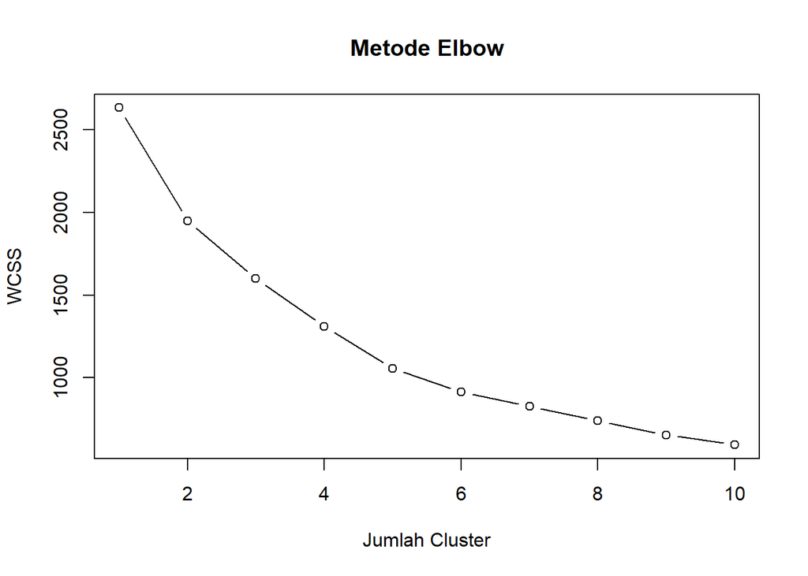

```r
plot(1:10,
     wcss,
     type = "b",
     xlab = "Jumlah Cluster",
     ylab = "WCSS",
     main = "Metode Elbow")
```

Hasil k optimal:

```r
k_optimal <- 2
```

# Clustering K-Means

```r
set.seed(123)

kmeans_final <- kmeans(data_scale,
                       centers = k_optimal,
                       nstart = 25)

kmeans_final
```

```
## K-means clustering with 2 clusters of sizes 41, 399
##
## Cluster means:
##         Fresh       Milk    Grocery      Frozen Detergents_Paper Delicassen
## 1  0.05283636  2.0659269  2.2407190  0.32219794        2.2585338  0.8039597
## 2 -0.00542930 -0.2122882 -0.2302493 -0.03310806       -0.2320799 -0.0826124
##
## Clustering vector:
##   [1] 2 2 2 2 2 2 2 2 2 2 2 2 2 2 2 2 2 2 2 2 2 2 2 1 2 2 2 2 1 2 2 2 2 2 2 2 2
##  [38] 2 2 2 2 2 2 1 2 1 1 1 2 1 2 2 2 2 2 2 1 2 2 2 2 1 2 2 2 1 2 2 2 2 2 2 2 2
##  [75] 2 2 2 1 2 2 2 2 2 2 2 1 1 2 2 2 2 2 1 2 2 2 2 2 2 2 2 2 2 2 2 2 2 2 2 2 2
## [112] 2 2 2 2 2 2 2 2 2 2 2 2 2 2 2 2 2 2 2 2 2 2 2 2 2 2 2 2 2 2 2 2 2 2 1 2 2
## [149] 2 2 2 2 2 2 2 1 2 2 2 2 2 2 2 1 2 1 2 2 2 2 2 1 2 2 2 2 2 2 2 2 2 1 2 1 2
## [186] 2 2 2 2 2 2 2 2 2 2 2 2 2 2 2 1 1 2 2 2 1 2 2 2 1 2 1 2 2 2 2 1 2 2 2 2 2
## [223] 2 2 2 2 2 2 2 2 2 2 2 2 2 2 2 2 2 2 2 2 2 2 2 2 2 2 2 2 2 1 2 2 2 2 2 2 2
## [260] 2 2 2 2 2 2 2 2 2 2 2 2 2 2 2 2 2 2 2 2 2 2 2 2 2 2 2 2 2 2 2 2 2 2 2 2 2
## [297] 2 2 2 2 2 1 2 2 1 2 1 2 2 1 2 2 1 2 2 2 2 2 2 1 2 2 2 2 2 1 2 2 2 2 2 1 2
## [334] 1 2 2 2 2 2 2 2 2 2 1 2 2 2 2 2 1 2 1 2 2 2 2 2 2 2 2 2 2 2 2 2 2 2 2 2 2
## [371] 2 2 2 2 2 2 2 2 2 2 2 2 2 2 2 2 2 2 2 2 2 2 2 2 2 2 2 2 2 2 2 2 2 2 2 2 2
## [408] 2 2 2 2 2 2 2 2 2 2 2 2 2 2 2 2 2 2 2 2 2 2 2 2 2 2 2 2 2 2 1 2 2
##
## Within cluster sum of squares by cluster:
## [1] 966.3860 982.9619
##  (between_SS / total_SS =  26.0 %)
##
## Available components:
##
## [1] "cluster"      "centers"      "totss"        "withinss"     "tot.withinss"
## [6] "betweenss"    "size"         "iter"         "ifault"
```

```r
table(kmeans_final$cluster)
```

```
##
##   1   2
##  41 399
```

Hasil K-Means membagi 440 pelanggan menjadi 2 cluster. Cluster 1 (41 pelanggan) adalah kelompok pelanggan dengan belanja sangat tinggi terutama di Milk, Grocery, dan Detergents_Paper, ketiganya berada jauh di atas rata-rata pelanggan lain. Sementara Cluster 2 (399 pelanggan) adalah pelanggan reguler yang belanjanya biasa saja di semua kategori, tidak ada yang menonjol.

Nilai between_SS/total_SS sebesar $26%$ menunjukkan bahwa kedua cluster belum terpisah secara bersih, masih banyak pelanggan yang karakteristiknya mirip satu sama lain sehingga batas antar kelompok tidak terlalu tegas.

## Visualisasi K-Means

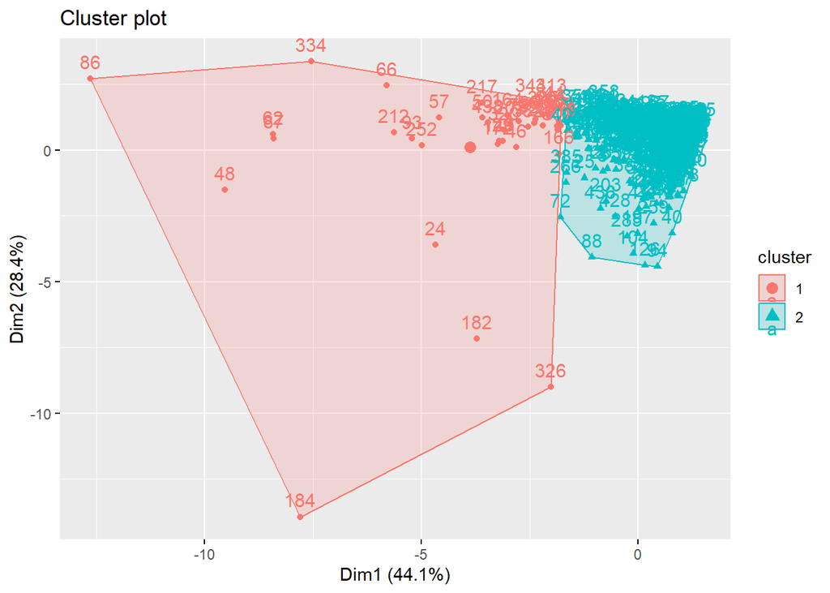

```r
fviz_cluster(kmeans_final,
             data = data_scale)
```

## Validasi Silhouette K-Means

```r
sil_kmeans <- silhouette(
  kmeans_final$cluster,
  dist(data_scale)
)


mean(sil_kmeans[,3])
```

```
## [1] 0.5914656
```

Nilai 0.591 masuk kategori cukup baik. Sebagian besar pelanggan sudah ditempatkan di cluster yang tepat, namun ada sejumlah observasi yang posisinya ambigu, bisa jadi berada di batas antara dua cluster.

## Validasi Bootstrap K-Means

```r
set.seed(123)

boot_kmeans <- clusterboot(
  data_scale,
  B = 100,
  clustermethod = kmeansCBI,
  k = k_optimal
)
```

[output not shown]

[output cut: 45 more lines]

[output not shown]

```r
boot_kmeans
```

```
## * Cluster stability assessment *
## Cluster method:  kmeans
## Full clustering results are given as parameter result
## of the clusterboot object, which also provides further statistics
## of the resampling results.
## Number of resampling runs:  100
##
## Number of clusters found in data:  2
##
##  Clusterwise Jaccard bootstrap (omitting multiple points) mean:
## [1] 0.9453606 0.6417636
## dissolved:
## [1]  0 28
## recovered:
## [1] 97 41
```

```r
boot_kmeans$bootmean
```

```
## [1] 0.9453606 0.6417636
```

Cluster 1 (Jaccard = 0.945) → sangat stabil. Dalam 100 kali bootstrap, cluster ini tidak pernah hilang (dissolved = 0) dan 97 kali berhasil terbentuk kembali. Artinya 41 pelanggan di cluster ini memang punya pola belanja yang sangat mirip satu sama lain.

Cluster 2 (Jaccard = 0.642) → kurang stabil. Sebanyak 28 kali cluster ini hilang dan hanya 41 kali berhasil terbentuk kembali dari 100 iterasi. Artinya 399 pelanggan di cluster ini kemiripannya tidak sekuat Cluster 1.

# Hierarchical Clustering

## Menghitung Matriks Jarak

```r
dist_data <- dist(data_scale, method = "manhattan")
```

## Membentuk Dendrogram

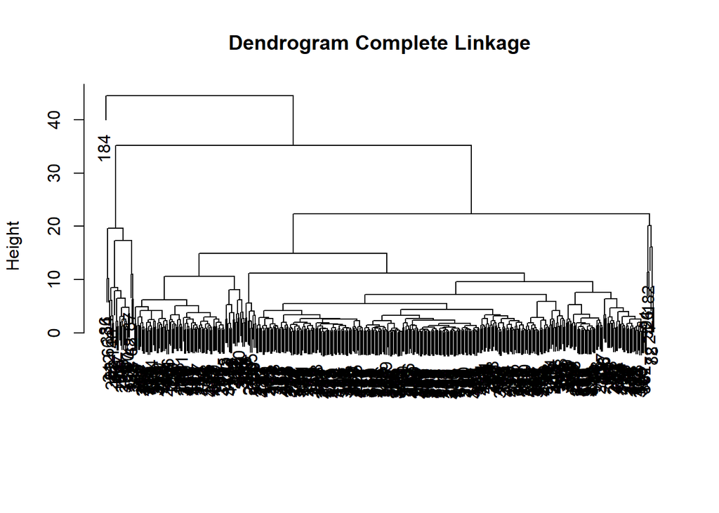

```r
hc_complete <- hclust(
  dist_data,
  method = "complete"
)

plot(hc_complete,
     main = "Dendrogram Complete Linkage",
     xlab = "",
     sub = "")
```

## Membentuk Cluster

Karena hasil sebelumnya menunjukkan:

```r
k_optimal <- 2
```

maka:

```r
cluster_complete <- cutree(
  hc_complete,
  k = k_optimal
)

table(cluster_complete)
```

```
## cluster_complete
##   1   2
## 439   1
```

Ketika dendrogram dipotong pada k = 2, hasilnya sangat tidak seimbang: 439 observasi berada pada satu cluster dan hanya 1 observasi pada cluster lainnya. Hal ini menunjukkan bahwa Complete Linkage mengidentifikasi satu titik ekstrem (outlier) yang sangat berbeda dari observasi lainnya sehingga dipisahkan menjadi cluster tersendiri.

Menampilkan Batas Cluster pada Dendrogram

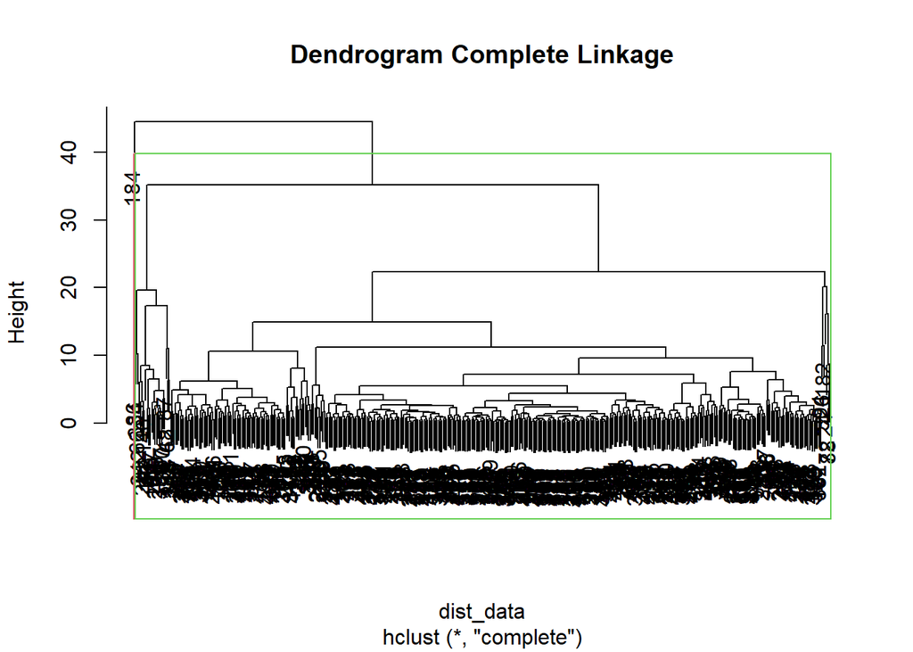

```r
plot(hc_complete,
     main = "Dendrogram Complete Linkage")

rect.hclust(
  hc_complete,
  k = k_optimal,
  border = 2:5
)
```

## Validasi Silhouette Hierarchical

```r
sil_complete <- silhouette(
  cluster_complete,
  dist_data
)

mean(sil_complete[,3])
```

```
## [1] 0.8518715
```

Nilai silhouette yang sangat tinggi ini pada awalnya terlihat menunjukkan kualitas clustering yang sangat baik. Namun, interpretasi ini perlu ditinjau lebih hati-hati.

Pada hasil clustering, salah satu cluster hanya berisi 1 observasi. Dalam kondisi seperti ini, nilai silhouette untuk observasi tersebut secara otomatis mendekati 1 karena tidak ada anggota lain dalam cluster yang sama untuk dibandingkan.

Akibatnya, rata-rata silhouette menjadi terinflasi (artificially high) dan tidak sepenuhnya mencerminkan kualitas segmentasi secara nyata. Oleh karena itu, nilai ini tidak dapat dijadikan satu-satunya ukuran kualitas clustering.

## Validasi Bootstrap Hierarchical

```r
set.seed(123)

boot_complete <- clusterboot(
  data_scale,
  B = 100,
  clustermethod = hclustCBI,
  method = "complete",
  k = k_optimal
)
```

[output not shown]

[output cut: 45 more lines]

[output not shown]

```r
boot_complete
```

```
## * Cluster stability assessment *
## Cluster method:  hclust/cutree
## Full clustering results are given as parameter result
## of the clusterboot object, which also provides further statistics
## of the resampling results.
## Number of resampling runs:  100
##
## Number of clusters found in data:  2
##
##  Clusterwise Jaccard bootstrap (omitting multiple points) mean:
## [1] 0.9939239 0.6050000
## dissolved:
## [1]  0 44
## recovered:
## [1] 100  56
```

```r
boot_complete$bootmean
```

```
## [1] 0.9939239 0.6050000
```

Cluster 1 (Jaccard 0.9939) sangat stabil karena hampir seluruh data selalu kembali membentuk cluster yang sama pada setiap bootstrap iterasi (recovered 100/100).

Cluster 2 (Jaccard 0.6050) kurang stabil karena sering “hilang” (dissolved 44 kali). Hal ini terjadi karena cluster hanya berisi 1 observasi sehingga sangat sensitif terhadap perubahan sampel bootstrap.

## Perbandingan Metode Clustering

### Perbandingan Nilai Silhouette

```r
data.frame(
  Metode = c("K-Means",
             "Hierarchical Complete"),
  Silhouette = c(
    mean(sil_kmeans[,3]),
    mean(sil_complete[,3])
  )
)
```

```
##                  Metode Silhouette
## 1               K-Means  0.5914656
## 2 Hierarchical Complete  0.8518715
```

Secara numerik, Hierarchical Complete terlihat lebih unggul. Namun, nilai tersebut bersifat bias karena distribusi cluster yang ekstrem (439 vs 1), sehingga tidak mencerminkan segmentasi yang seimbang.

### Perbandingan Nilai Bootstrap

```r
data.frame(
  Metode = c("K-Means",
             "Hierarchical Complete"),
  Cluster1 = c(
    boot_kmeans$bootmean[1],
    boot_complete$bootmean[1]
  ),
  Cluster2 = c(
    boot_kmeans$bootmean[2],
    boot_complete$bootmean[2]
  )
)
```

```
##                  Metode  Cluster1  Cluster2
## 1               K-Means 0.9453606 0.6417636
## 2 Hierarchical Complete 0.9939239 0.6050000
```

Cluster 1 pada kedua metode menunjukkan stabilitas yang tinggi, ditandai dengan nilai Jaccard yang mendekati 1. Hal ini menunjukkan bahwa anggota cluster konsisten terbentuk kembali pada proses bootstrap.

Cluster 2 memiliki stabilitas lebih rendah. Pada K-Means hal ini menunjukkan batas pemisahan antar cluster yang kurang tegas, sedangkan pada Hierarchical disebabkan ukuran cluster yang sangat kecil sehingga sensitif terhadap perubahan sampel.

Dari hasil perbandingan, K-Means dipilih sebagai metode terbaik meskipun memiliki nilai silhouette yang lebih rendah (0.591 dibanding 0.852 pada Hierarchical). Hal ini karena hasil Hierarchical Complete Linkage tidak memberikan segmentasi yang bermakna secara praktis, yaitu hanya memisahkan satu observasi dari sebagian besar data, sehingga tidak membentuk kelompok yang representatif.

Sebaliknya, K-Means menghasilkan dua kelompok yang lebih seimbang dan dapat diinterpretasikan: satu kelompok dengan pola belanja lebih tinggi (41 pelanggan) dan kelompok lainnya dengan pola belanja lebih rendah (399 pelanggan).

Karakteristik Cluster Terbaik

```r
aggregate(
  data_clust,
  by = list(
    Cluster = kmeans_final$cluster
  ),
  mean
)
```

```
##   Cluster    Fresh      Milk  Grocery   Frozen Detergents_Paper Delicassen
## 1       1 12668.54 21043.585 29245.20 4636.098         13649.85   3792.122
## 2       2 11931.63  4229.499  5763.18 2911.203          1774.97   1291.895
```

# Kesimpulan Akhir

Berdasarkan hasil analisis clustering pada data Wholesale Customers dengan 440 observasi dan 6 variabel belanja, metode K-Means dengan k = 2 dipilih sebagai metode terbaik. Meskipun metode Hierarchical Complete Linkage menghasilkan nilai silhouette yang lebih tinggi (0.852 dibanding 0.591 pada K-Means), hasil tersebut tidak memberikan segmentasi yang bermakna secara praktis karena hanya memisahkan satu observasi dari seluruh data.

Sebaliknya, K-Means menghasilkan dua kelompok yang lebih representatif, yaitu 41 pelanggan dengan pola belanja tinggi terutama pada variabel Milk, Grocery, dan Detergents_Paper, serta 399 pelanggan dengan pola belanja lebih rendah dan relatif merata di seluruh kategori. Selain itu, stabilitas Cluster 1 yang tinggi (Jaccard = 0.945) menunjukkan bahwa kelompok tersebut terbentuk secara konsisten dan memiliki pola belanja yang kuat.

Secara keseluruhan, K-Means memberikan hasil segmentasi yang lebih seimbang, stabil, dan mudah diinterpretasikan untuk analisis perilaku pelanggan.